# HW7_TS

Curtis Zhuang

2021/5/17

#### **Question 1:**

#### Load the data and calculate the average cost of a night’s accommodation in Victoria each month (i.e., Cost variable).

1. Plot the CPI and Cost time series.

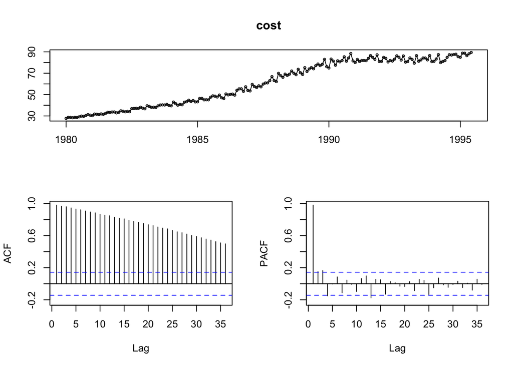

```r
load('motel.rda')

RN <- motel[,1]
TAKING <- motel[,2]
CPI <- motel[,3]

# Deriving cost
cost <- TAKING*1000/RN # Unit Thousand Australian dollars

# ts for cost
tsdisplay(cost)
```

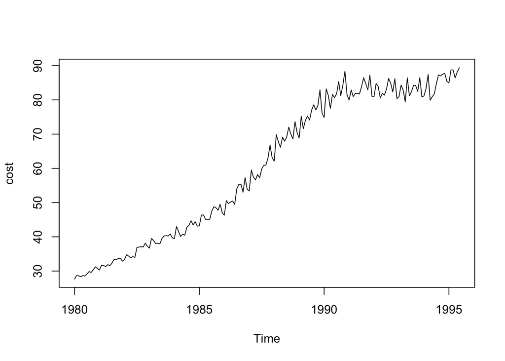

```r
plot(cost)
```

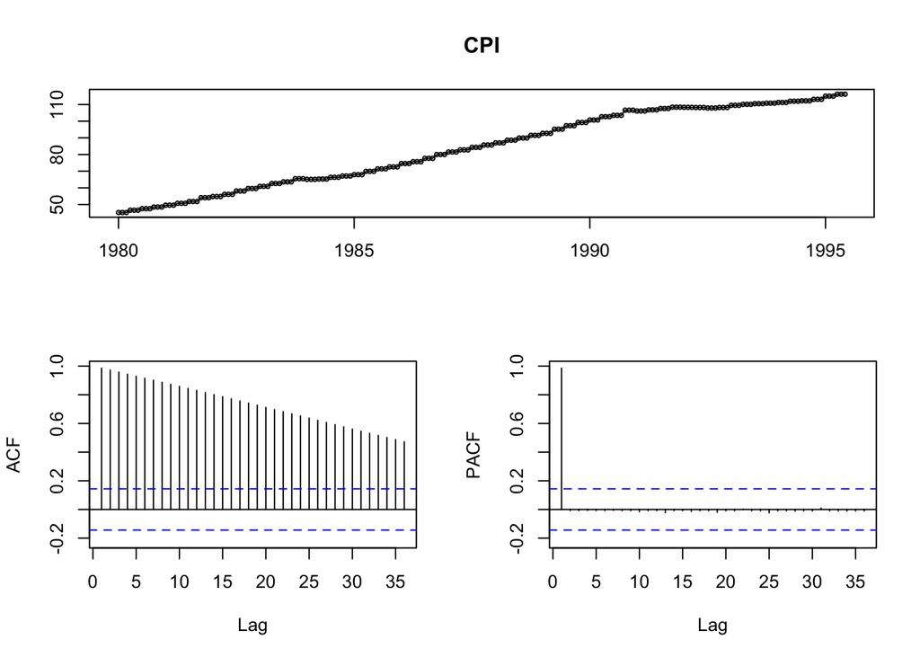

```r
# ts for cpi
tsdisplay(CPI)
```

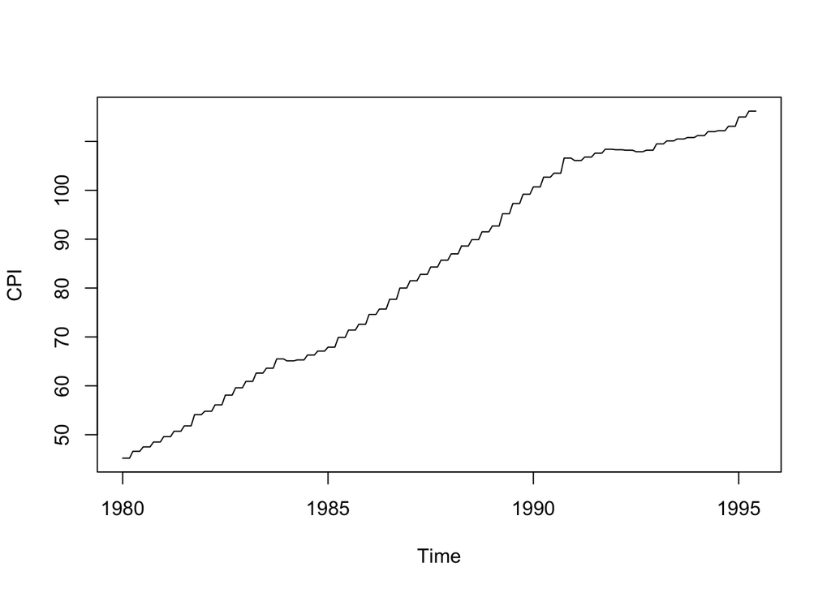

```r
plot(CPI)
```

2. Plot the Cost time series against the CPI time series and calculate the correlation between CPI and Cost. Discuss your results and explain why the logarithms of both variables need to be taken before fitting any models.

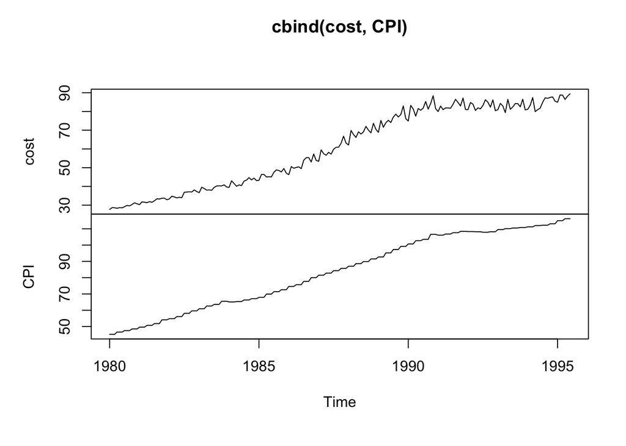

```r
# cost against cpi
plot.ts(cbind(cost, CPI))
```

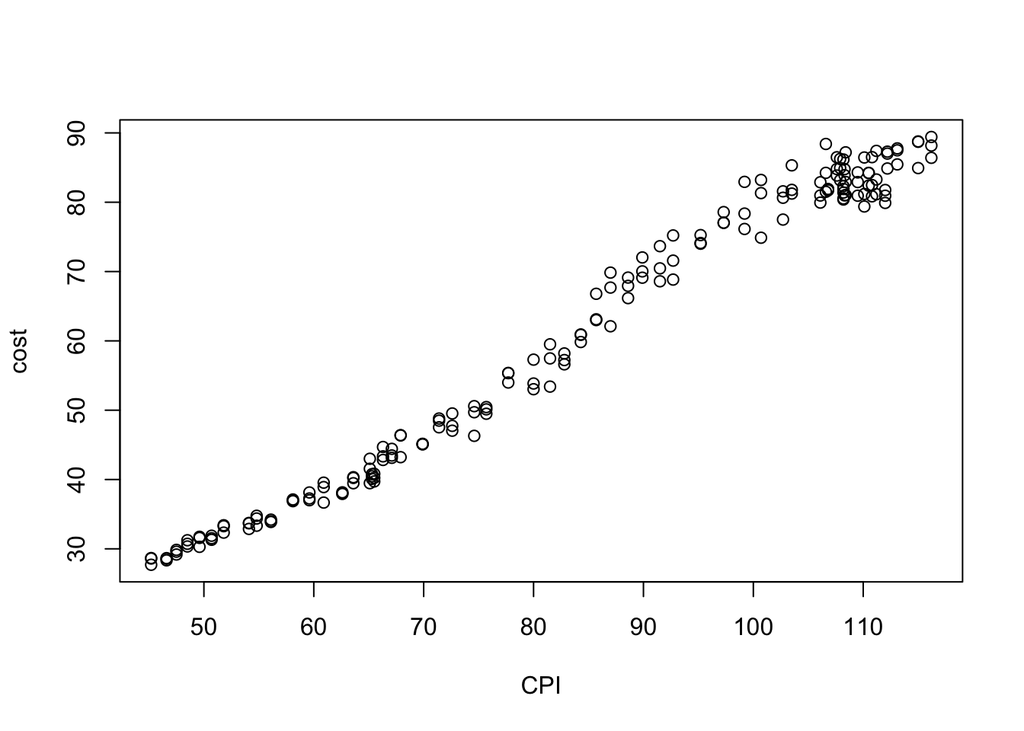

```r
plot(CPI, cost, type = 'p')
```

```r
cor(CPI, cost)
```

```
## [1] 0.9907186
```

**When we look at the variance for cost, we see that it grows larger within time which is not ideal, so we need to tranform. Also ARMAX need stationary of data but both CPI and cost are not stationary**

3. Plot the 𝑙𝑜𝑔(𝐶𝑃𝐼) and 𝑙𝑜𝑔(𝐶𝑜𝑠𝑡) time series and calculate the correlation between the logarithms of both CPI and Cost.

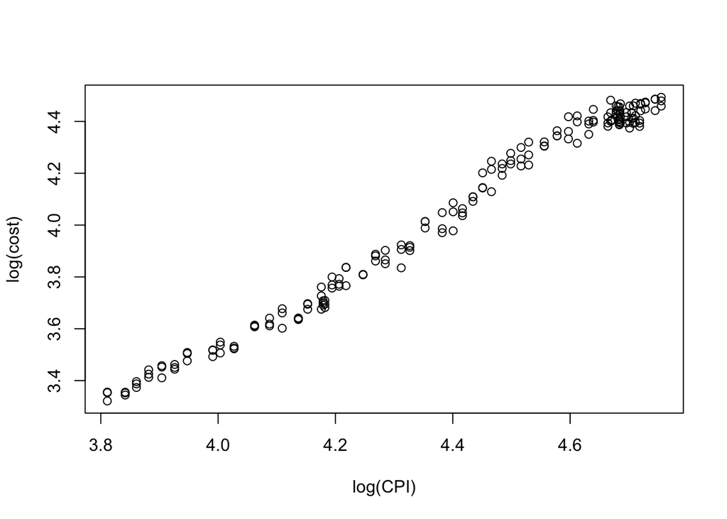

```r
# log
plot(log(CPI), log(cost), type = 'p')
```

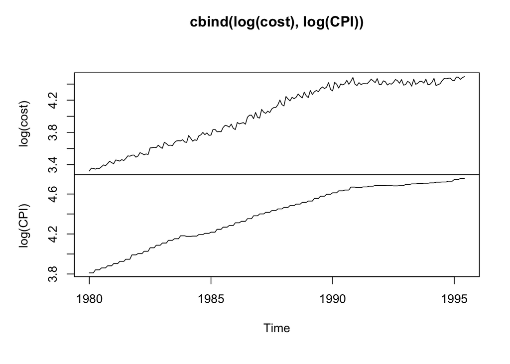

```r
plot.ts(cbind(log(cost), log(CPI)))
```

```r
# correlation
cor(log(cost), log(CPI))
```

```
## [1] 0.9929902
```

#### **Question 2:**

1. Use the linear model with time series components function tslm() to fit a linear model to the 𝑙𝑜𝑔(𝐶𝑜𝑠𝑡) time series as a function of the 𝑙𝑜𝑔(𝐶𝑃𝐼) time series (i.e., CPI ➔ Independent variable, Cost➔ Dependent variable).
2. Plot 𝑙𝑜𝑔(𝐶𝑃𝐼) against 𝑙𝑜𝑔(𝐶𝑜𝑠𝑡) and the fitted trend.
3. Use the summary() function to summarize the generated model , and the checkresiduals() function to evaluate the residuals.

#### Discuss your results.

```r
model1 <- tslm(log(cost) ~ log(CPI))
model1
```

```
##
## Call:
## tslm(formula = log(cost) ~ log(CPI))
##
## Coefficients:
## (Intercept)     log(CPI)
##      -1.682        1.303
```

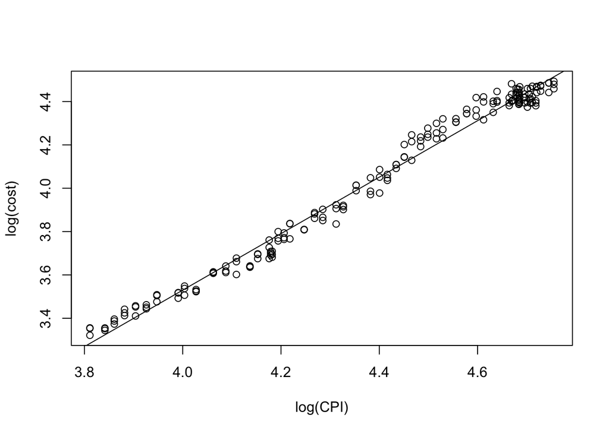

```r
plot(log(CPI), log(cost))
abline(-1.682, 1.303)
```

```r
summary(model1)
```

```
##
## Call:
## tslm(formula = log(cost) ~ log(CPI))
##
## Residuals:
##       Min        1Q    Median        3Q       Max
## -0.102841 -0.033939 -0.002071  0.030363  0.108670
##
## Coefficients:
##             Estimate Std. Error t value Pr(>|t|)
## (Intercept) -1.68246    0.05032  -33.44   <2e-16 ***
## log(CPI)     1.30339    0.01144  113.96   <2e-16 ***
## ---
## Signif. codes:  0 '***' 0.001 '**' 0.01 '*' 0.05 '.' 0.1 ' ' 1
##
## Residual standard error: 0.04487 on 184 degrees of freedom
## Multiple R-squared:  0.986,  Adjusted R-squared:  0.986
## F-statistic: 1.299e+04 on 1 and 184 DF,  p-value: < 2.2e-16
```

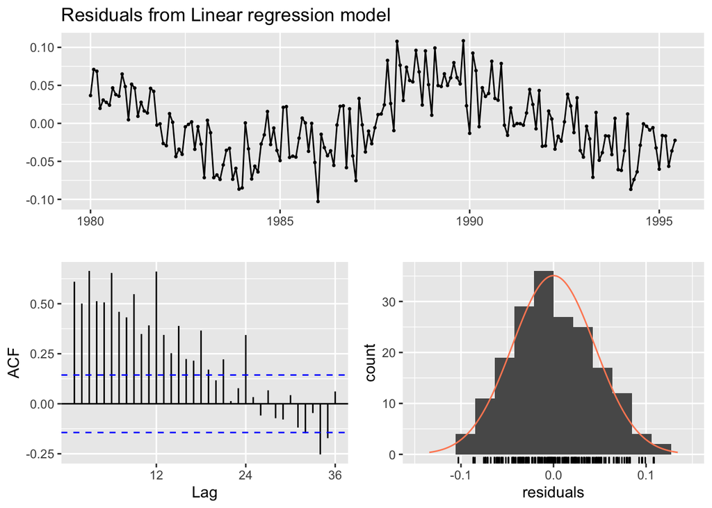

```
##
##  Breusch-Godfrey test for serial correlation of order up to 24
##
## data:  Residuals from Linear regression model
## LM test = 148.84, df = 24, p-value < 2.2e-16
```

```r
checkresiduals(model1)
```

**From both ACF graph and Breusch-Godfrey test which has significant p value, we wee that there is serial correlation. And looking at the log(cost) against log(cpi) graph we see there also shows very high correlation as the points aligned with the trend.**

#### **Question 3:**

#### Use the auto.arima() function to fit an appropriate regression model with ARIMA errors to the Cost and CPI time series(i.e., CPI ➔ Independent variable, Cost➔ Dependent variable). Set the Order of seasonaldifferencing argument, D, to 1 and the ‘lambda’ argument to 0 to reflect a logarithmic transformation.

1. Use the summary() function to summarize the generated model.
2. Use the checkresiduals() function to evaluate the residuals.

#### Discuss your results.

```r
model2 <- auto.arima(cost, lambda = 0, seasonal = TRUE, trace = TRUE, xreg = CPI, D = 1)
```

```
##
##  Fitting models using approximations to speed things up...
##
##  ARIMA(2,1,2)(1,1,1)[12]                    : -764.4321
##  ARIMA(0,1,0)(0,1,0)[12]                    : -672.462
##  ARIMA(1,1,0)(1,1,0)[12]                    : -751.2479
##  ARIMA(0,1,1)(0,1,1)[12]                    : -769.7472
##  ARIMA(0,1,1)(0,1,0)[12]                    : -717.3536
##  ARIMA(0,1,1)(1,1,1)[12]                    : -769.774
##  ARIMA(0,1,1)(1,1,0)[12]                    : -767.685
##  ARIMA(0,1,1)(2,1,1)[12]                    : -761.3721
##  ARIMA(0,1,1)(1,1,2)[12]                    : -768.5302
##  ARIMA(0,1,1)(0,1,2)[12]                    : -770.1273
##  ARIMA(0,1,0)(0,1,2)[12]                    : -728.4742
##  ARIMA(1,1,1)(0,1,2)[12]                    : -768.0373
##  ARIMA(0,1,2)(0,1,2)[12]                    : -767.9916
##  ARIMA(1,1,0)(0,1,2)[12]                    : -755.8352
##  ARIMA(1,1,2)(0,1,2)[12]                    : -766.062
##
##  Now re-fitting the best model(s) without approximations...
##
##  ARIMA(0,1,1)(0,1,2)[12]                    : -863.7854
##
##  Best model: Regression with ARIMA(0,1,1)(0,1,2)[12] errors
```

```r
summary(model2)
```

```
## Series: cost
## Regression with ARIMA(0,1,1)(0,1,2)[12] errors
## Box Cox transformation: lambda= 0
##
## Coefficients:
##           ma1     sma1    sma2    xreg
##       -0.5516  -0.6160  0.1374  0.0099
## s.e.   0.0602   0.0785  0.1009  0.0025
##
## sigma^2 estimated as 0.0003728:  log likelihood=437.07
## AIC=-864.14   AICc=-863.79   BIC=-848.38
##
## Training set error measures:
##                       ME     RMSE       MAE        MPE     MAPE      MASE
## Training set -0.08012207 1.307136 0.8968091 -0.1126491 1.349787 0.2115032
##                     ACF1
## Training set -0.06269298
```

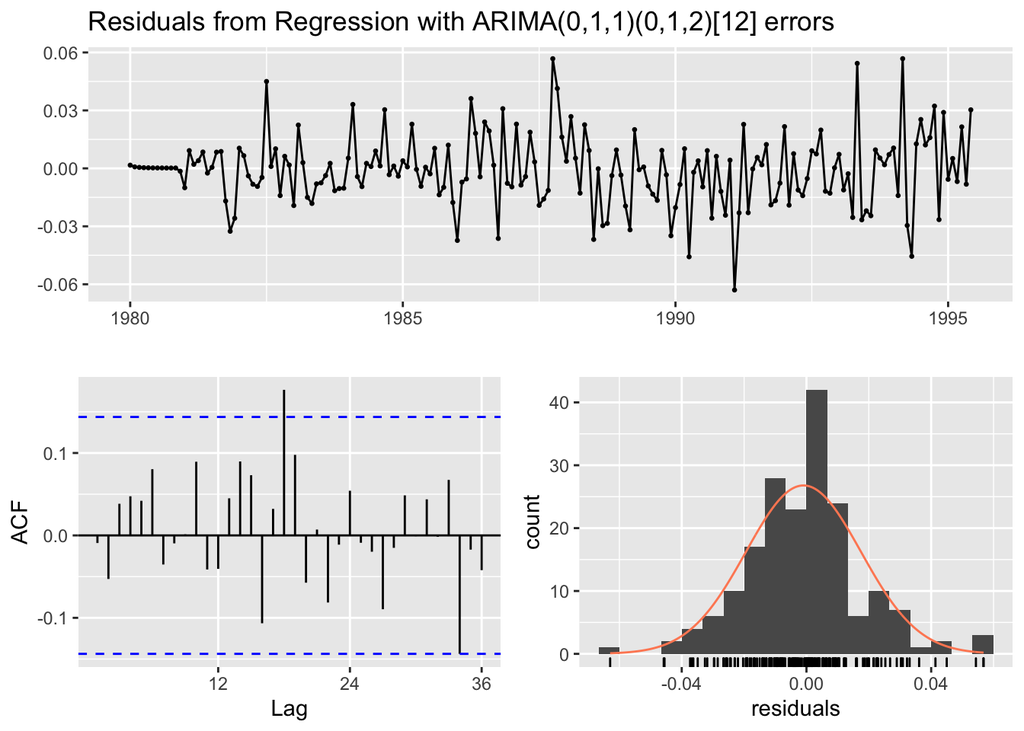

```
##
##  Ljung-Box test
##
## data:  Residuals from Regression with ARIMA(0,1,1)(0,1,2)[12] errors
## Q* = 22.342, df = 20, p-value = 0.3223
##
## Model df: 4.   Total lags used: 24
```

```r
checkresiduals(model2)
```

**As we limit D = 1, our final Arima model is Arima(0,1,1)(0,1,2)[12] with AICc = -863.79 and BIC = -848.38. When looking at the residuals, we see that from ACF it is almost white noise and Ljung-Box test comfirmed that residuals may be stationary.**

#### **Question 4:**

1. Calculate and plot a naïve forecast of CPI for the next 18 months.
2. Forecast and plot the average price per room (i.e., Cost) for the next 18 months using the fitted model from Question 3 and the naïve forecast of CPI.

#### Discuss your results.

```r
# Using Naive
CPI_pred <- naive(CPI, h = 18)
CPI_pred
```

```
##          Point Forecast    Lo 80    Hi 80    Lo 95    Hi 95
## Jul 1995          116.2 115.1893 117.2107 114.6543 117.7457
## Aug 1995          116.2 114.7707 117.6293 114.0141 118.3859
## Sep 1995          116.2 114.4495 117.9505 113.5228 118.8772
## Oct 1995          116.2 114.1786 118.2214 113.1086 119.2914
## Nov 1995          116.2 113.9401 118.4599 112.7437 119.6563
## Dec 1995          116.2 113.7244 118.6756 112.4138 119.9862
## Jan 1996          116.2 113.5260 118.8740 112.1105 120.2895
## Feb 1996          116.2 113.3414 119.0586 111.8281 120.5719
## Mar 1996          116.2 113.1680 119.2320 111.5629 120.8371
## Apr 1996          116.2 113.0040 119.3960 111.3121 121.0879
## May 1996          116.2 112.8480 119.5520 111.0735 121.3265
## Jun 1996          116.2 112.6989 119.7011 110.8455 121.5545
## Jul 1996          116.2 112.5560 119.8440 110.6269 121.7731
## Aug 1996          116.2 112.4184 119.9816 110.4165 121.9835
## Sep 1996          116.2 112.2857 120.1143 110.2135 122.1865
## Oct 1996          116.2 112.1573 120.2427 110.0172 122.3828
## Nov 1996          116.2 112.0329 120.3671 109.8269 122.5731
## Dec 1996          116.2 111.9121 120.4879 109.6422 122.7578
```

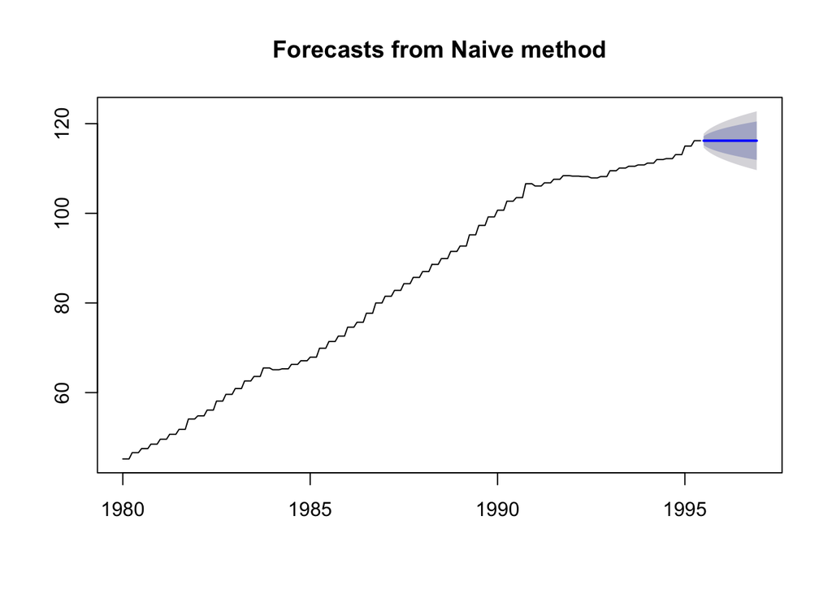

```r
plot(CPI_pred)
```

```r
# Using ARIMA
pred <- forecast(model2, xreg = CPI_pred$mean, h = 18)
pred
```

```
##          Point Forecast    Lo 80    Hi 80    Lo 95     Hi 95
## Jul 1995       89.97440 87.77538 92.22852 86.63312  93.44455
## Aug 1995       92.49848 90.02378 95.04121 88.74067  96.41543
## Sep 1995       91.97103 89.31530 94.70572 87.94063  96.18614
## Oct 1995       90.33995 87.55335 93.21525 86.11317  94.77421
## Nov 1995       93.11977 90.07549 96.26695 88.50444  97.97579
## Dec 1995       88.33935 85.29739 91.48980 83.72971  93.20277
## Jan 1996       87.39830 84.24415 90.67054 82.62078  92.45207
## Feb 1996       90.64320 87.22891 94.19113 85.47386  96.12517
## Mar 1996       91.94087 88.33878 95.68983 86.48943  97.73591
## Apr 1996       86.40297 82.89243 90.06217 81.09217  92.06156
## May 1996       88.90656 85.16998 92.80707 83.25595  94.94068
## Jun 1996       88.69944 84.85178 92.72157 82.88299  94.92407
## Jul 1996       90.40999 86.09547 94.94072 83.89549  97.43035
## Aug 1996       92.92288 88.28029 97.80961 85.91730 100.49968
## Sep 1996       92.50991 87.69031 97.59441 85.24145 100.39814
## Oct 1996       91.16304 86.22711 96.38151 83.72331  99.26387
## Nov 1996       93.39758 88.15714 98.94954 85.50311 102.02095
## Dec 1996       89.13543 83.96542 94.62378 81.35109  97.66464
```

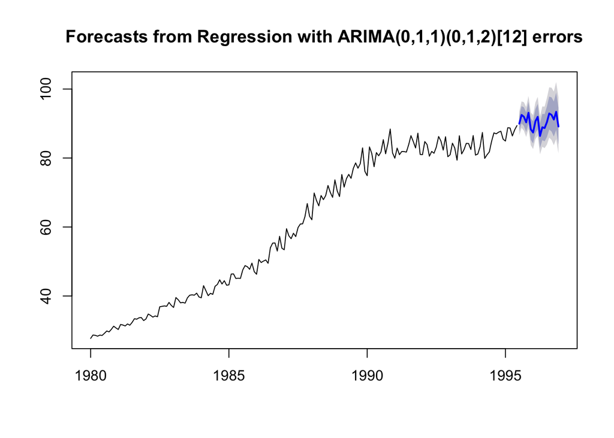

```r
plot(pred)
```

**We see that we used naive prediction of CPI as inputs for future CPI to predict cost. And the results are as showed from the graph we seems to be a good prediction as it takes the trend and shows simliar patterns compared to previous results. But this model does not include the interaction between the variables as with the high correlation between them, they will affect each other in both directions and that is why we will use Varma model next.**

#### **Question 5:**

1. Use the VAR() function to fit a VAR(10) model to the 𝑙𝑜𝑔(𝐶𝑜𝑠𝑡) and 𝑙𝑜𝑔(𝐶𝑃𝐼) time series. Set the ‘type’ and ‘season’ arguments to ‘both’ and 12, respectively.
2. Forecast and plot the average price per room (i.e., Cost) and CPI for the next 18 months using your fitted model.
3. Plot the residuals’ ACF.

#### Discuss your results.

```r
#### a.
variables <- cbind(log(cost), log(CPI))
# VARselect(variables, lag.max = 8, type = 'const')$selection
var1 <- VAR(variables, p = 10, type = 'both', season = 12)
serial.test(var1, lags.pt = 10, type = 'PT.asymptotic')
```

```
##
##  Portmanteau Test (asymptotic)
##
## data:  Residuals of VAR object var1
## Chi-squared = 5.8494, df = 0, p-value < 2.2e-16
```

```r
var_pred <- forecast(var1, h = 18)
var_pred
```

```
## log.cost.
##          Point Forecast    Lo 80    Hi 80    Lo 95    Hi 95
## Jul 1995       4.514645 4.489981 4.539308 4.476925 4.552365
## Aug 1995       4.536276 4.509773 4.562779 4.495744 4.576809
## Sep 1995       4.533696 4.505100 4.562293 4.489962 4.577431
## Oct 1995       4.528037 4.496555 4.559518 4.479890 4.576183
## Nov 1995       4.566296 4.532298 4.600294 4.514300 4.618291
## Dec 1995       4.522756 4.485991 4.559522 4.466529 4.578984
## Jan 1996       4.509267 4.468613 4.549920 4.447092 4.571441
## Feb 1996       4.575961 4.532186 4.619737 4.509013 4.642910
## Mar 1996       4.560384 4.514233 4.606535 4.489802 4.630966
## Apr 1996       4.536550 4.487475 4.585625 4.461496 4.611604
## May 1996       4.558217 4.506481 4.609954 4.479094 4.637341
## Jun 1996       4.548503 4.494235 4.602772 4.465507 4.631500
## Jul 1996       4.586123 4.529139 4.643107 4.498973 4.673273
## Aug 1996       4.609708 4.550002 4.669415 4.518396 4.701021
## Sep 1996       4.602543 4.540478 4.664607 4.507623 4.697463
## Oct 1996       4.595150 4.530644 4.659656 4.496497 4.693804
## Nov 1996       4.635577 4.568633 4.702521 4.533195 4.737959
## Dec 1996       4.585999 4.516808 4.655189 4.480181 4.691816
##
## log.CPI.
##          Point Forecast    Lo 80    Hi 80    Lo 95    Hi 95
## Jul 1995       4.767494 4.761683 4.773306 4.758606 4.776383
## Aug 1995       4.768845 4.760977 4.776713 4.756812 4.780878
## Sep 1995       4.768835 4.759494 4.778176 4.754549 4.783121
## Oct 1995       4.790082 4.779094 4.801069 4.773278 4.806885
## Nov 1995       4.791220 4.778822 4.803617 4.772259 4.810180
## Dec 1995       4.791700 4.778065 4.805335 4.770847 4.812553
## Jan 1996       4.801693 4.786230 4.817155 4.778045 4.825341
## Feb 1996       4.801568 4.784466 4.818670 4.775412 4.827724
## Mar 1996       4.801304 4.782916 4.819691 4.773183 4.829424
## Apr 1996       4.816690 4.796297 4.837084 4.785501 4.847879
## May 1996       4.817551 4.795327 4.839775 4.783562 4.851540
## Jun 1996       4.817614 4.793810 4.841417 4.781210 4.854018
## Jul 1996       4.832976 4.807371 4.858582 4.793816 4.872137
## Aug 1996       4.833398 4.806078 4.860717 4.791616 4.875179
## Sep 1996       4.833378 4.804564 4.862192 4.789311 4.877445
## Oct 1996       4.851759 4.821216 4.882301 4.805048 4.898469
## Nov 1996       4.851846 4.819657 4.884034 4.802618 4.901073
## Dec 1996       4.851667 4.818051 4.885284 4.800255 4.903079
```

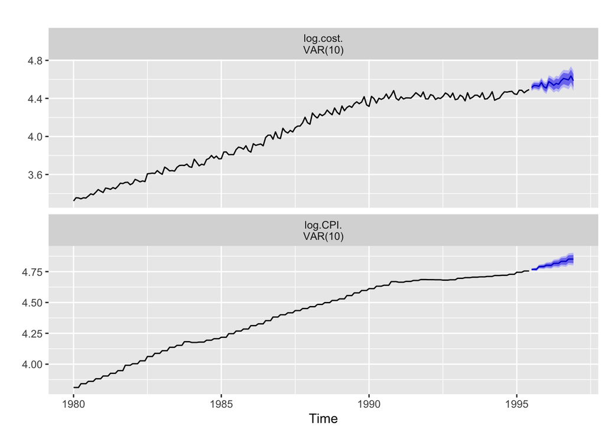

```r
autoplot(var_pred)
```

```r
summary(var1)
```

```
##
## VAR Estimation Results:
## =========================
## Endogenous variables: log.cost., log.CPI.
## Deterministic variables: both
## Sample size: 176
## Log Likelihood: 1185.453
## Roots of the characteristic polynomial:
## 0.9752 0.9588 0.9588 0.9494 0.9494 0.8857 0.8857 0.8607 0.8607 0.858 0.858 0.7962 0.7962 0.7867 0.7765 0.7765 0.7244 0.7244 0.4201 0.4201
## Call:
## VAR(y = variables, p = 10, type = "both", season = 12L)
##
##
## Estimation results for equation log.cost.:
## ==========================================
## log.cost. = log.cost..l1 + log.CPI..l1 + log.cost..l2 + log.CPI..l2 + log.cost..l3 + log.CPI..l3 + log.cost..l4 + log.CPI..l4 + log.cost..l5 + log.CPI..l5 + log.cost..l6 + log.CPI..l6 + log.cost..l7 + log.CPI..l7 + log.cost..l8 + log.CPI..l8 + log.cost..l9 + log.CPI..l9 + log.cost..l10 + log.CPI.…
##
##                 Estimate Std. Error t value Pr(>|t|)
## log.cost..l1   3.918e-01  8.566e-02   4.573 1.03e-05 ***
## log.CPI..l1    3.234e-02  3.326e-01   0.097  0.92268
## log.cost..l2   2.361e-01  9.172e-02   2.574  0.01107 *
## log.CPI..l2    5.203e-01  4.448e-01   1.170  0.24403
## log.cost..l3   2.619e-01  9.295e-02   2.818  0.00552 **
## log.CPI..l3   -3.801e-01  4.452e-01  -0.854  0.39463
## log.cost..l4   6.684e-02  9.548e-02   0.700  0.48503
## log.CPI..l4    2.113e-01  4.446e-01   0.475  0.63539
## log.cost..l5   1.064e-01  9.430e-02   1.128  0.26113
## log.CPI..l5   -7.446e-01  4.443e-01  -1.676  0.09596 .
## log.cost..l6   1.080e-01  9.370e-02   1.153  0.25095
## log.CPI..l6    5.488e-01  4.524e-01   1.213  0.22715
## log.cost..l7  -4.795e-02  9.377e-02  -0.511  0.60986
## log.CPI..l7   -1.154e-02  4.533e-01  -0.025  0.97972
## log.cost..l8  -1.478e-01  9.248e-02  -1.598  0.11216
## log.CPI..l8   -5.395e-02  4.469e-01  -0.121  0.90407
## log.cost..l9  -2.313e-02  9.246e-02  -0.250  0.80285
## log.CPI..l9    2.196e-01  4.515e-01   0.486  0.62744
## log.cost..l10 -5.534e-03  8.677e-02  -0.064  0.94924
## log.CPI..l10  -2.696e-01  3.302e-01  -0.817  0.41554
## const         -9.512e-02  1.711e-01  -0.556  0.57905
## trend         -3.844e-05  1.821e-04  -0.211  0.83310
```

[output cut: 62 more lines]

```
## Residual standard error: 0.004535 on 143 degrees of freedom
## Multiple R-Squared: 0.9998,  Adjusted R-squared: 0.9997
## F-statistic: 1.855e+04 on 32 and 143 DF,  p-value: < 2.2e-16
##
##
##
## Covariance matrix of residuals:
##           log.cost.  log.CPI.
## log.cost. 3.704e-04 1.699e-05
## log.CPI.  1.699e-05 2.057e-05
##
## Correlation matrix of residuals:
##           log.cost. log.CPI.
## log.cost.    1.0000   0.1947
## log.CPI.     0.1947   1.0000
```

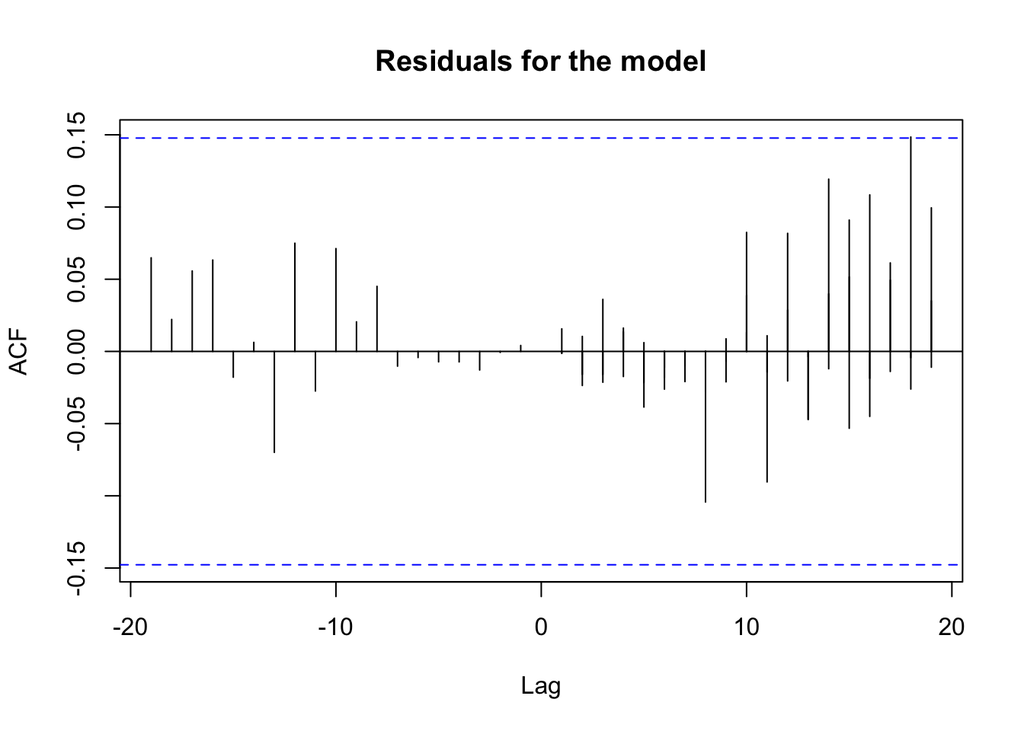

```r
acf(residuals(var1), main = 'Residuals for the model')
```

**By using VARMA model, we see that compared to the naive method, CPI also shows a upward trend, in turn this reflected in a more stable trend compared to ARIMA model. By looking at the residuals, we see that acf is stationary so we have a good model which captures the positive relationship between cost of motel and the CPI.**